# R Notebook Homework 1

**Principles of Data Visualization and Introduction to ggplot2**

I have provided you with data about the 5,000 fastest growing companies in the US, as compiled by Inc. magazine. lets read this in:

```r
inc <- read.csv("https://raw.githubusercontent.com/charleyferrari/CUNY_DATA_608/master/module1/Data/inc5000_data.csv", header= TRUE)
```

And lets preview this data:

```r
head(inc)
```

```
##   Rank                         Name Growth_Rate   Revenue
## 1    1                         Fuhu      421.48 1.179e+08
## 2    2        FederalConference.com      248.31 4.960e+07
## 3    3                The HCI Group      245.45 2.550e+07
## 4    4                      Bridger      233.08 1.900e+09
## 5    5                       DataXu      213.37 8.700e+07
## 6    6 MileStone Community Builders      179.38 4.570e+07
##                       Industry Employees         City State
## 1 Consumer Products & Services       104   El Segundo    CA
## 2          Government Services        51     Dumfries    VA
## 3                       Health       132 Jacksonville    FL
## 4                       Energy        50      Addison    TX
## 5      Advertising & Marketing       220       Boston    MA
## 6                  Real Estate        63       Austin    TX
```

```r
summary(inc)
```

```
##       Rank          Name            Growth_Rate         Revenue
##  Min.   :   1   Length:5001        Min.   :  0.340   Min.   :2.000e+06
##  1st Qu.:1252   Class :character   1st Qu.:  0.770   1st Qu.:5.100e+06
##  Median :2502   Mode  :character   Median :  1.420   Median :1.090e+07
##  Mean   :2502                      Mean   :  4.612   Mean   :4.822e+07
##  3rd Qu.:3751                      3rd Qu.:  3.290   3rd Qu.:2.860e+07
##  Max.   :5000                      Max.   :421.480   Max.   :1.010e+10
##
##    Industry           Employees           City              State
##  Length:5001        Min.   :    1.0   Length:5001        Length:5001
##  Class :character   1st Qu.:   25.0   Class :character   Class :character
##  Mode  :character   Median :   53.0   Mode  :character   Mode  :character
##                     Mean   :  232.7
##                     3rd Qu.:  132.0
##                     Max.   :66803.0
##                     NA's   :12
```

Think a bit on what these summaries mean. Use the space below to add some more relevant non-visual exploratory information you think helps you understand this data:

### Industries having most fast growing companies (in desc order)

```r
# Insert your code here, create more chunks as necessary

describe(inc$Employees)
```

```
##    vars    n   mean      sd median trimmed   mad min   max range  skew kurtosis
## X1    1 4989 232.72 1353.13     53   81.78 53.37   1 66803 66802 29.81  1268.67
##       se
## X1 19.16
```

```r
I <- data.frame(inc %>% group_by(Industry) %>% tally()) %>% arrange(desc(n))

kable(I) %>% scroll_box(height = "300px")
```

| Industry | n |
| --- | --- |
| IT Services | 733 |
| Business Products & Services | 482 |
| Advertising & Marketing | 471 |
| Health | 355 |
| Software | 342 |
| Financial Services | 260 |
| Manufacturing | 256 |
| Consumer Products & Services | 203 |
| Retail | 203 |
| Government Services | 202 |
| Human Resources | 196 |
| Construction | 187 |
| Logistics & Transportation | 155 |
| Food & Beverage | 131 |
| Telecommunications | 129 |
| Energy | 109 |
| Real Estate | 96 |
| Education | 83 |
| Engineering | 74 |
| Security | 73 |
| Travel & Hospitality | 62 |
| Media | 54 |
| Environmental Services | 51 |
| Insurance | 50 |
| Computer Hardware | 44 |

```r
prop.table(table(inc$Industry))
```

```
##
##      Advertising & Marketing Business Products & Services
##                   0.09418116                   0.09638072
##            Computer Hardware                 Construction
##                   0.00879824                   0.03739252
## Consumer Products & Services                    Education
##                   0.04059188                   0.01659668
##                       Energy                  Engineering
##                   0.02179564                   0.01479704
##       Environmental Services           Financial Services
##                   0.01019796                   0.05198960
##              Food & Beverage          Government Services
##                   0.02619476                   0.04039192
##                       Health              Human Resources
##                   0.07098580                   0.03919216
##                    Insurance                  IT Services
##                   0.00999800                   0.14657069
##   Logistics & Transportation                Manufacturing
##                   0.03099380                   0.05118976
##                        Media                  Real Estate
##                   0.01079784                   0.01919616
##                       Retail                     Security
##                   0.04059188                   0.01459708
##                     Software           Telecommunications
##                   0.06838632                   0.02579484
##         Travel & Hospitality
##                   0.01239752
```

### States having most fast growing companies (in desc order)

```r
S <- data.frame(inc %>% group_by(State) %>% tally()) %>% arrange(desc(n))

kable(S) %>% scroll_box(height = "300px")
```

| State | n |
| --- | --- |
| CA | 701 |
| TX | 387 |
| NY | 311 |
| VA | 283 |
| FL | 282 |
| IL | 273 |
| GA | 212 |
| OH | 186 |
| MA | 182 |
| PA | 164 |
| NJ | 158 |
| NC | 137 |
| CO | 134 |
| MD | 131 |
| WA | 130 |
| MI | 126 |
| AZ | 100 |
| UT | 95 |
| MN | 88 |
| TN | 82 |
| WI | 79 |
| IN | 69 |
| MO | 59 |
| AL | 51 |
| CT | 50 |
| OR | 49 |
| SC | 48 |
| OK | 46 |
| DC | 43 |
| KY | 40 |
| KS | 38 |
| LA | 37 |
| IA | 28 |
| NE | 27 |
| NV | 26 |
| NH | 24 |
| ID | 17 |
| DE | 16 |
| RI | 16 |
| ME | 13 |
| MS | 12 |
| ND | 10 |
| AR | 9 |
| HI | 7 |
| VT | 6 |
| NM | 5 |
| MT | 4 |
| SD | 3 |
| AK | 2 |
| WV | 2 |
| WY | 2 |
| PR | 1 |

```r
prop.table(table(inc$State))
```

```
##
##         AK         AL         AR         AZ         CA         CO         CT
## 0.00039992 0.01019796 0.00179964 0.01999600 0.14017197 0.02679464 0.00999800
##         DC         DE         FL         GA         HI         IA         ID
## 0.00859828 0.00319936 0.05638872 0.04239152 0.00139972 0.00559888 0.00339932
##         IL         IN         KS         KY         LA         MA         MD
## 0.05458908 0.01379724 0.00759848 0.00799840 0.00739852 0.03639272 0.02619476
##         ME         MI         MN         MO         MS         MT         NC
## 0.00259948 0.02519496 0.01759648 0.01179764 0.00239952 0.00079984 0.02739452
##         ND         NE         NH         NJ         NM         NV         NY
## 0.00199960 0.00539892 0.00479904 0.03159368 0.00099980 0.00519896 0.06218756
##         OH         OK         OR         PA         PR         RI         SC
## 0.03719256 0.00919816 0.00979804 0.03279344 0.00019996 0.00319936 0.00959808
##         SD         TN         TX         UT         VA         VT         WA
## 0.00059988 0.01639672 0.07738452 0.01899620 0.05658868 0.00119976 0.02599480
##         WI         WV         WY
## 0.01579684 0.00039992 0.00039992
```

## Question 1

Create a graph that shows the distribution of companies in the dataset by State (ie how many are in each state). There are a lot of States, so consider which axis you should use. This visualization is ultimately going to be consumed on a ‘portrait’ oriented screen (ie taller than wide), which should further guide your layout choices.

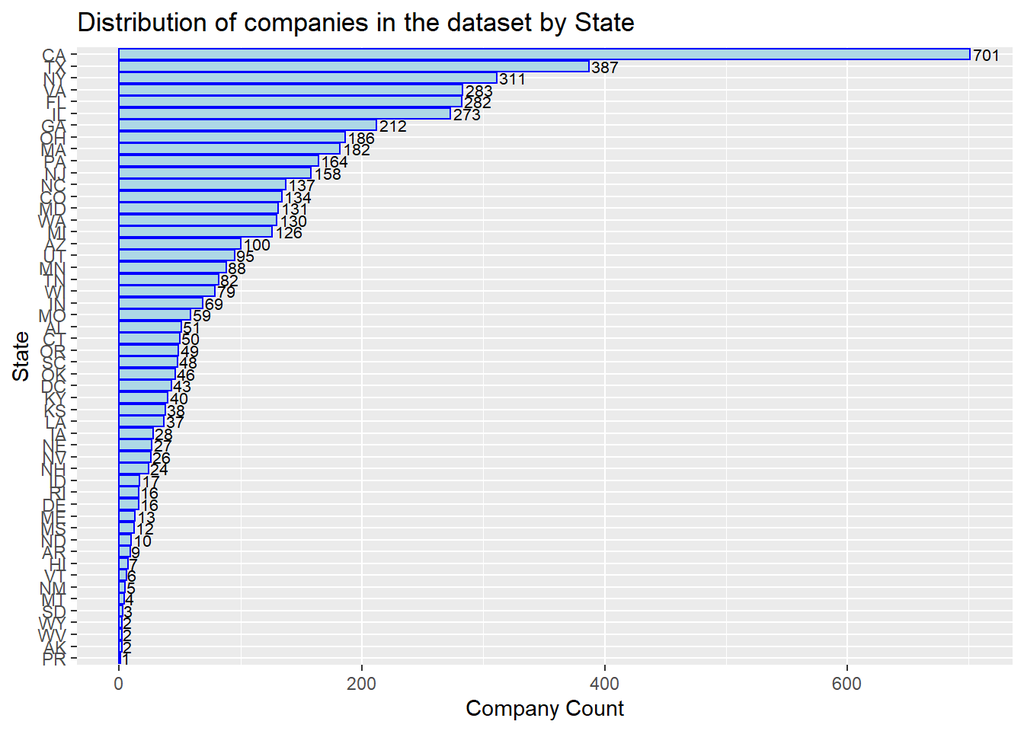

```r
# Answer Question 1 here

X <- inc %>% group_by(State) %>% summarise(counts = n()) %>% arrange(counts)

ggplot(X, aes(x = reorder(State, counts), y = counts)) + geom_bar(stat = "identity", fill='light blue',color='blue') + coord_flip() + geom_text(aes(label = counts), vjust = 0.5, hjust = -0.1, size=2.75) + ggtitle("Distribution of companies in the dataset by State") + xlab("State") + ylab("Company Count")
```

## Quesiton 2

Lets dig in on the state with the 3rd most companies in the data set. Imagine you work for the state and are interested in how many people are employed by companies in different industries. Create a plot that shows the average and/or median employment by industry for companies in this state (only use cases with full data, use R’s `complete.cases()` function.) In addition to this, your graph should show how variable the ranges are, and you should deal with outliers.

```r
# Answer Question 2 here

NY <- inc %>% filter(State == 'NY') %>% filter(complete.cases(.)) %>% group_by(Industry) %>% summarize(A=mean(Employees), M=median(Employees))

kable(NY) %>% scroll_box(height = "300px")
```

| Industry | A | M |
| --- | --- | --- |
| Advertising & Marketing | 58.43860 | 38.0 |
| Business Products & Services | 1492.46154 | 70.5 |
| Computer Hardware | 44.00000 | 44.0 |
| Construction | 61.00000 | 24.5 |
| Consumer Products & Services | 626.29412 | 25.0 |
| Education | 59.85714 | 50.5 |
| Energy | 129.20000 | 120.0 |
| Engineering | 53.50000 | 54.5 |
| Environmental Services | 155.00000 | 155.0 |
| Financial Services | 144.30769 | 81.0 |
| Food & Beverage | 76.44444 | 41.0 |
| Government Services | 17.00000 | 17.0 |
| Health | 81.84615 | 45.0 |
| Human Resources | 437.54545 | 56.0 |
| Insurance | 32.50000 | 32.5 |
| IT Services | 204.09302 | 54.0 |
| Logistics & Transportation | 29.50000 | 23.5 |
| Manufacturing | 73.30769 | 30.0 |
| Media | 108.00000 | 45.0 |
| Real Estate | 18.25000 | 18.0 |
| Retail | 24.78571 | 13.5 |
| Security | 135.00000 | 32.5 |
| Software | 245.92308 | 80.0 |
| Telecommunications | 95.35294 | 31.0 |
| Travel & Hospitality | 547.71429 | 61.0 |

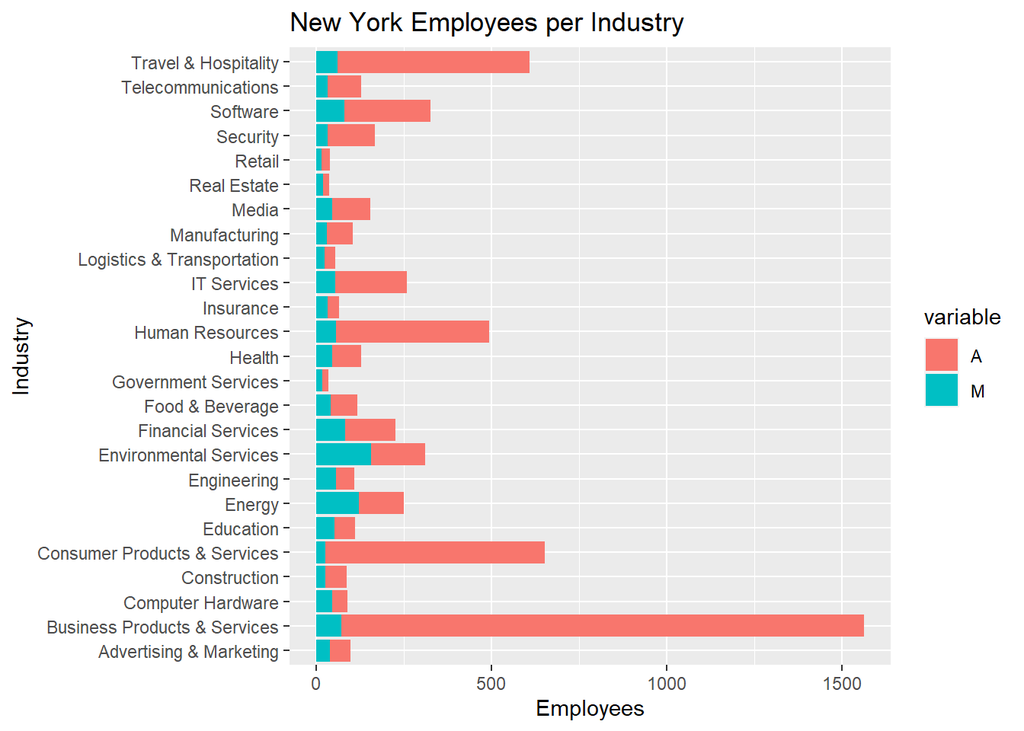

```r
ggplot(melt(NY, id.vars='Industry'), aes(x=Industry, y=value, fill=variable)) + geom_bar(stat='identity') + coord_flip() + ylab("Employees") + ggtitle("New York Employees per Industry")
```

To see the outliers properly boxplot can be used.

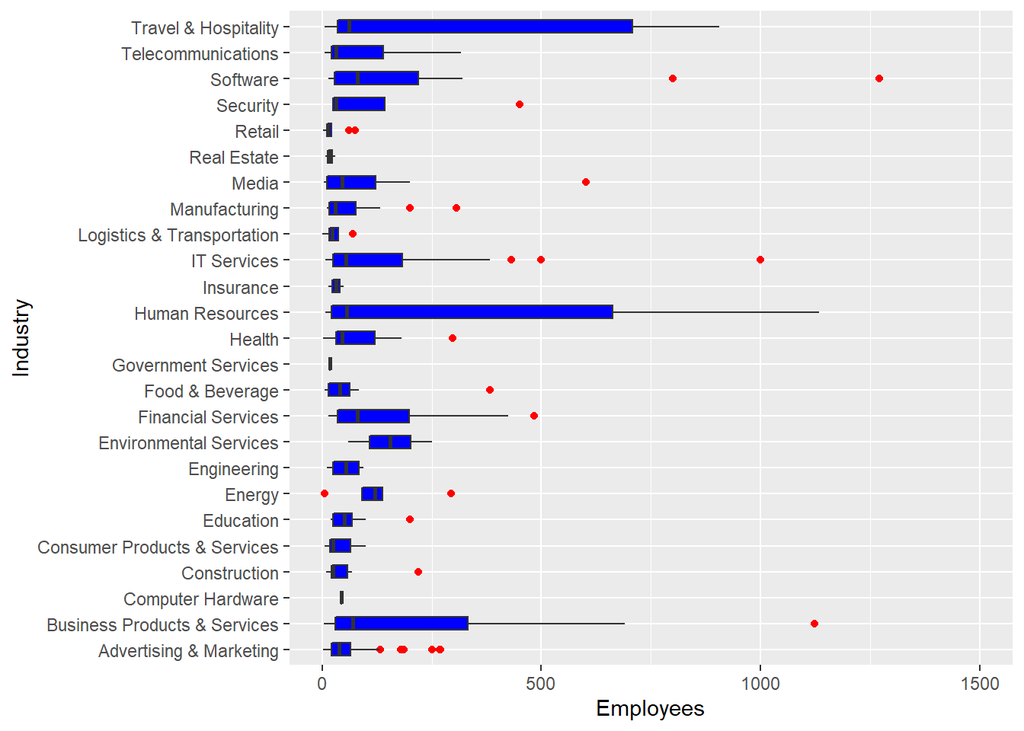

```r
NY_X <- inc %>% filter(State == 'NY') %>% filter(complete.cases(.)) %>% group_by(Industry)

ggplot(NY_X, aes(x=Industry, y=Employees)) + geom_boxplot(width = 0.5,fill='blue',outlier.colour="red") + coord_flip(ylim = c(0, 1500), expand = TRUE)
```

## Question 3

Now imagine you work for an investor and want to see which industries generate the most revenue per employee. Create a chart that makes this information clear. Once again, the distribution per industry should be shown.

```r
# Answer Question 3 here

NY_R <- NY_X %>%  mutate(R = Revenue/Employees) %>%  group_by(Industry) %>% summarize(A = mean(R), M = median(R))

kable(NY_R) %>% scroll_box(height = "300px")
```

| Industry | A | M |
| --- | --- | --- |
| Advertising & Marketing | 373403.5 | 255555.6 |
| Business Products & Services | 527816.9 | 203148.1 |
| Computer Hardware | 520454.5 | 520454.5 |
| Construction | 238694.5 | 238613.0 |
| Consumer Products & Services | 382942.6 | 222222.2 |
| Education | 112060.6 | 114848.5 |
| Energy | 8472533.5 | 283211.7 |
| Engineering | 215744.7 | 202998.1 |
| Environmental Services | 134366.7 | 134366.7 |
| Financial Services | 400174.4 | 219607.8 |
| Food & Beverage | 174630.9 | 120238.1 |
| Government Services | 158823.5 | 158823.5 |
| Health | 532491.0 | 155000.0 |
| Human Resources | 337366.3 | 175000.0 |
| Insurance | 371000.0 | 371000.0 |
| IT Services | 228816.1 | 164285.7 |
| Logistics & Transportation | 1245870.1 | 996285.7 |
| Manufacturing | 665818.6 | 217500.0 |
| Media | 333549.6 | 262500.0 |
| Real Estate | 383809.5 | 330952.4 |
| Retail | 520790.3 | 305000.0 |
| Security | 153277.8 | 149000.0 |
| Software | 143749.0 | 133333.3 |
| Telecommunications | 408143.4 | 410714.3 |
| Travel & Hospitality | 282089.8 | 223333.3 |

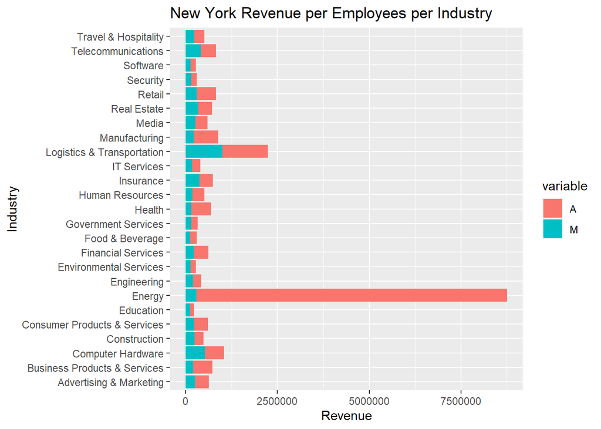

```r
ggplot(melt(NY_R, id.vars='Industry'), aes(x=Industry, y=value, fill=variable)) + geom_bar(stat='identity') + coord_flip() + ylab("Revenue") + ggtitle("New York Revenue per Employees per Industry")
```